# SDS 322E Project

Team 2

2022-09-30

This is our project for team 2, Flight Experience. The data contains information over 129,880 people who flew on different airplanes (with the same airline company though) and describes their plane ride experience. They rate their overall experience (from a scale of 1 to 5 where ‘0’ stands for “Not Applicable” , ‘1’ is “Least Satisfied” and ‘5’ is “Most Satisfied”) over a lot of different variables. There are also two columns that include data over their departure delay and arrival delay time. It’s a classification problem, and we will look at the variables that make the best ride for a passenger and determine if they would have categorized their ride as ‘satisfied’ or ’ ‘unsatisfied’ depending on their self-report.

Our goal: With this information, we will be able to help the company increase their retention rate with customers by being able to focus on what aspects of the flights that people enjoy the most.

References/Link to the data: The data is given by an airline organization. The actual name of the company is not given due to privacy. This is a link to the original dataset on Kaggle: https://www.kaggle.com/datasets/sjleshrac/airlines-customer-satisfaction

These are all the column names:

[1] “satisfaction” “Gender” “Customer.Type” “Age”  
[5] “Type.of.Travel” “Class” “Flight.Distance” “Seat.comfort”  
[9] “Departure.Arrival.time.convenient” “Food.and.drink” “Gate.location” “Inflight.wifi.service”  
[13] “Inflight.entertainment” “Online.support,” “Ease.of.Online.booking” “On.board.service”  
[17] “Leg.room.service” “Baggage.handling” “Checkin.service” “Cleanliness”  
[21] “Online.boarding” “Departure.Delay.in.Minutes” “Arrival.Delay.in.Minutes”

```r
library(ggplot2)
library(tidyverse)
library(cluster)
library(vtable)
```

##Reading in the excel file

```r
flight_df <- read.csv("Flight_Experience.csv") %>% data.frame()
head(flight_df)
```

```
##   satisfaction Gender  Customer.Type Age  Type.of.Travel    Class
## 1    satisfied Female Loyal Customer  65 Personal Travel      Eco
## 2    satisfied   Male Loyal Customer  47 Personal Travel Business
## 3    satisfied Female Loyal Customer  15 Personal Travel      Eco
## 4    satisfied Female Loyal Customer  60 Personal Travel      Eco
## 5    satisfied Female Loyal Customer  70 Personal Travel      Eco
## 6    satisfied   Male Loyal Customer  30 Personal Travel      Eco
##   Flight.Distance Seat.comfort Departure.Arrival.time.convenient Food.and.drink
## 1             265            0                                 0              0
## 2            2464            0                                 0              0
## 3            2138            0                                 0              0
## 4             623            0                                 0              0
## 5             354            0                                 0              0
## 6            1894            0                                 0              0
##   Gate.location Inflight.wifi.service Inflight.entertainment Online.support
```

[output cut: 27 more lines]

##Getting column information

```r
flight_df %>% glimpse()
```

```
## Rows: 129,880
## Columns: 23
## $ satisfaction                      <chr> "satisfied", "satisfied", "satisfied…
## $ Gender                            <chr> "Female", "Male", "Female", "Female"…
## $ Customer.Type                     <chr> "Loyal Customer", "Loyal Customer", …
## $ Age                               <int> 65, 47, 15, 60, 70, 30, 66, 10, 56, …
## $ Type.of.Travel                    <chr> "Personal Travel", "Personal Travel"…
## $ Class                             <chr> "Eco", "Business", "Eco", "Eco", "Ec…
## $ Flight.Distance                   <int> 265, 2464, 2138, 623, 354, 1894, 227…
## $ Seat.comfort                      <int> 0, 0, 0, 0, 0, 0, 0, 0, 0, 0, 0, 0, …
## $ Departure.Arrival.time.convenient <int> 0, 0, 0, 0, 0, 0, 0, 0, 0, 0, 0, 0, …
## $ Food.and.drink                    <int> 0, 0, 0, 0, 0, 0, 0, 0, 0, 0, 0, 0, …
## $ Gate.location                     <int> 2, 3, 3, 3, 3, 3, 3, 3, 3, 3, 3, 4, …
## $ Inflight.wifi.service             <int> 2, 0, 2, 3, 4, 2, 2, 2, 5, 2, 3, 2, …
## $ Inflight.entertainment            <int> 4, 2, 0, 4, 3, 0, 5, 0, 3, 0, 3, 0, …
## $ Online.support                    <int> 2, 2, 2, 3, 4, 2, 5, 2, 5, 2, 3, 2, …
## $ Ease.of.Online.booking            <int> 3, 3, 2, 1, 2, 2, 5, 2, 4, 2, 3, 2, …
## $ On.board.service                  <int> 3, 4, 3, 1, 2, 5, 5, 3, 4, 2, 3, 3, …
## $ Leg.room.service                  <int> 0, 4, 3, 0, 0, 4, 0, 3, 0, 4, 0, 2, …
## $ Baggage.handling                  <int> 3, 4, 4, 1, 2, 5, 5, 4, 1, 5, 1, 5, …
## $ Checkin.service                   <int> 5, 2, 4, 4, 4, 5, 5, 5, 5, 3, 2, 2, …
## $ Cleanliness                       <int> 3, 3, 4, 1, 2, 4, 5, 4, 4, 4, 3, 5, …
## $ Online.boarding                   <int> 2, 2, 2, 3, 5, 2, 3, 2, 4, 2, 5, 2, …
## $ Departure.Delay.in.Minutes        <int> 0, 310, 0, 0, 0, 0, 17, 0, 0, 30, 47…
## $ Arrival.Delay.in.Minutes          <int> 0, 305, 0, 0, 0, 0, 15, 0, 0, 26, 48…
```

##Determining how many nulls there are

```r
nulls <- flight_df %>% summarize_all(function(x) sum(is.na(x)))
t(nulls)
```

```
##                                   [,1]
## satisfaction                         0
## Gender                               0
## Customer.Type                        0
## Age                                  0
## Type.of.Travel                       0
## Class                                0
## Flight.Distance                      0
## Seat.comfort                         0
## Departure.Arrival.time.convenient    0
## Food.and.drink                       0
## Gate.location                        0
## Inflight.wifi.service                0
## Inflight.entertainment               0
## Online.support                       0
## Ease.of.Online.booking               0
## On.board.service                     0
## Leg.room.service                     0
## Baggage.handling                     0
## Checkin.service                      0
## Cleanliness                          0
## Online.boarding                      0
## Departure.Delay.in.Minutes           0
## Arrival.Delay.in.Minutes           393
```

There are NA’s in the dataset so lets clean it. Only column that has blanks is Arrival.Delay.in.Minutes

##Let’s create a summary statstics table

```r
num <- flight_df %>% select(where(is.numeric))
st(num)
```

Summary Statistics

| Variable | N | Mean | Std. Dev. | Min | Pctl. 25 | Pctl. 75 | Max |
| --- | --- | --- | --- | --- | --- | --- | --- |
| Age | 129880 | 39.428 | 15.119 | 7 | 27 | 51 | 85 |
| Flight.Distance | 129880 | 1981.409 | 1027.116 | 50 | 1359 | 2544 | 6951 |
| Seat.comfort | 129880 | 2.839 | 1.393 | 0 | 2 | 4 | 5 |
| Departure.Arrival.time.convenient | 129880 | 2.991 | 1.527 | 0 | 2 | 4 | 5 |
| Food.and.drink | 129880 | 2.852 | 1.444 | 0 | 2 | 4 | 5 |
| Gate.location | 129880 | 2.99 | 1.306 | 0 | 2 | 4 | 5 |
| Inflight.wifi.service | 129880 | 3.249 | 1.319 | 0 | 2 | 4 | 5 |
| Inflight.entertainment | 129880 | 3.383 | 1.346 | 0 | 2 | 4 | 5 |
| Online.support | 129880 | 3.52 | 1.307 | 0 | 3 | 5 | 5 |
| Ease.of.Online.booking | 129880 | 3.472 | 1.306 | 0 | 2 | 5 | 5 |
| On.board.service | 129880 | 3.465 | 1.271 | 0 | 3 | 4 | 5 |
| Leg.room.service | 129880 | 3.486 | 1.292 | 0 | 2 | 5 | 5 |
| Baggage.handling | 129880 | 3.696 | 1.156 | 1 | 3 | 5 | 5 |
| Checkin.service | 129880 | 3.341 | 1.261 | 0 | 3 | 4 | 5 |
| Cleanliness | 129880 | 3.706 | 1.152 | 0 | 3 | 5 | 5 |
| Online.boarding | 129880 | 3.353 | 1.299 | 0 | 2 | 4 | 5 |
| Departure.Delay.in.Minutes | 129880 | 14.714 | 38.071 | 0 | 0 | 12 | 1592 |
| Arrival.Delay.in.Minutes | 129487 | 15.091 | 38.466 | 0 | 0 | 13 | 1584 |

##Let’s determine the overall satisfaction of the passengers

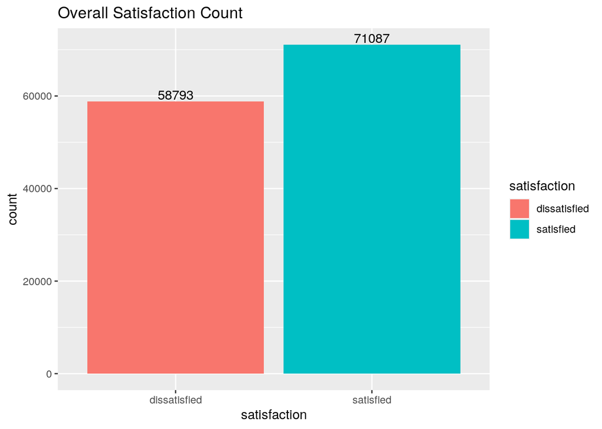

```r
flight_df %>% ggplot(aes(x = satisfaction, fill = satisfaction)) + geom_bar(position="stack", stat="count") + geom_text(stat="count", aes(label=..count..), position=position_dodge(width=0.9), vjust=-0.2) + ggtitle("Overall Satisfaction Count")
```

##Variables that have the highest rating for zero

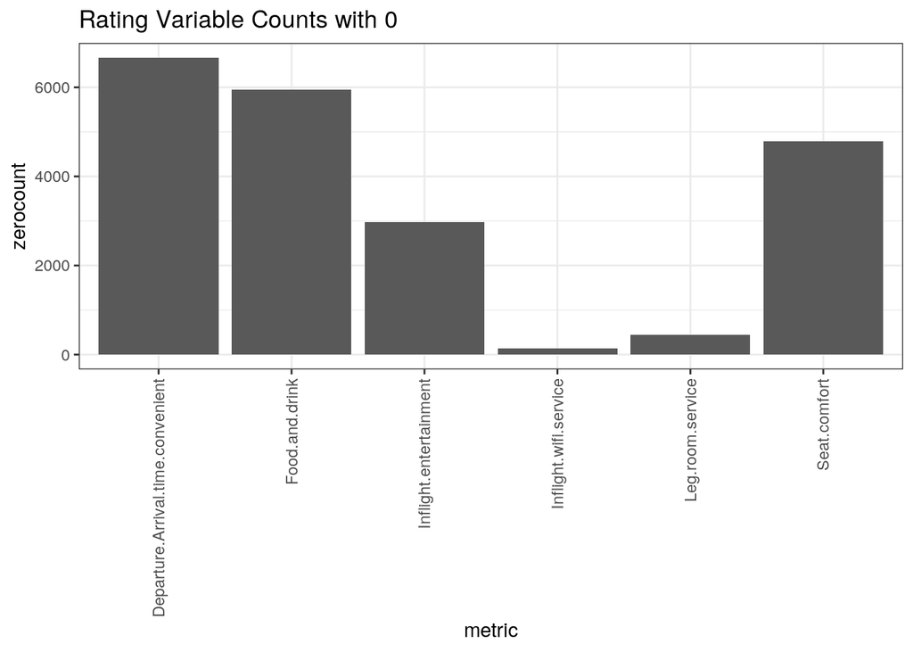

```r
df <- flight_df[ , 8:21]

df_rating <- df %>% summarise_all(function(x){sum(x==0)}) %>%
  gather(metric, zerocount) %>% filter(zerocount > 100)


ggplot(df_rating,aes(x=metric,y=zerocount)) + geom_bar(stat="identity") + theme_bw() + theme(axis.text.x = element_text(angle = 90, vjust = 0.5, hjust=1)) + ggtitle("Rating Variable Counts with 0")
```

```r
df <- flight_df %>% select_if(is.numeric) %>% na.omit()
cormat <- df %>% cor()


cormat %>% as.data.frame %>% rownames_to_column("var1")
```

```
##                                 var1           Age Flight.Distance Seat.comfort
## 1                                Age  1.0000000000    -0.249438178  0.008474937
## 2                    Flight.Distance -0.2494381776     1.000000000 -0.042476218
## 3                       Seat.comfort  0.0084749369    -0.042476218  1.000000000
## 4  Departure.Arrival.time.convenient  0.0389045982     0.001380637  0.434944690
## 5                     Food.and.drink  0.0154957058    -0.004806365  0.716007667
## 6                      Gate.location -0.0008049599    -0.002321616  0.405358235
## 7              Inflight.wifi.service  0.0140367279     0.012313559  0.129151961
## 8             Inflight.entertainment  0.1302542340    -0.027344333  0.426487945
## 9                     Online.support  0.1212867293    -0.031859699  0.120153416
## 10            Ease.of.Online.booking  0.0717278697    -0.022325502  0.211576238
## 11                  On.board.service  0.0665097673    -0.032421850  0.121182929
## 12                  Leg.room.service  0.0836836105    -0.030220028  0.136160590
## 13                  Baggage.handling -0.0155537358     0.019652907  0.118557154
## 14                   Checkin.service  0.0315557704     0.002530924  0.041264611
```

[output cut: 99 more lines]

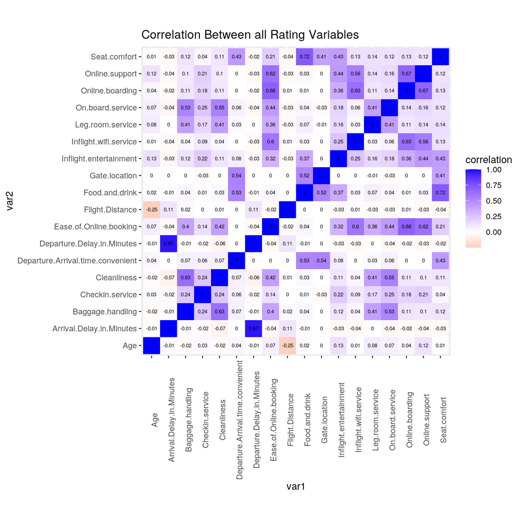

```r
tidycor <- cormat %>%
  as.data.frame %>%
  rownames_to_column("var1") %>%
  pivot_longer(-1, names_to = "var2", values_to = "correlation")


tidycor %>% ggplot(aes(var1, var2, fill=correlation)) +
  geom_tile() +
  scale_fill_gradient2(low="red", mid="white", high = "blue") +
  geom_text(aes(label=round(correlation,2)),color = "black", size = 2)+ #overlays correlation values
  theme(axis.text.x = element_text(angle = 90)) + #flips the x-axis labels
  coord_fixed() + ggtitle("Correlation Between all Rating Variables")
```

Correlation map between satisfaction and rating variables

```r
flight_df_numeric <- flight_df %>% mutate(satisfy = ifelse(satisfaction == "satisfied", 1, 0))





df2 <- flight_df_numeric %>% select_if(is.numeric) %>% na.omit()
cormat2 <- df2 %>% cor()


cormat2 %>% as.data.frame %>% rownames_to_column("var1")
```

```
##                                 var1           Age Flight.Distance Seat.comfort
## 1                                Age  1.0000000000    -0.249438178  0.008474937
## 2                    Flight.Distance -0.2494381776     1.000000000 -0.042476218
## 3                       Seat.comfort  0.0084749369    -0.042476218  1.000000000
## 4  Departure.Arrival.time.convenient  0.0389045982     0.001380637  0.434944690
## 5                     Food.and.drink  0.0154957058    -0.004806365  0.716007667
## 6                      Gate.location -0.0008049599    -0.002321616  0.405358235
## 7              Inflight.wifi.service  0.0140367279     0.012313559  0.129151961
## 8             Inflight.entertainment  0.1302542340    -0.027344333  0.426487945
## 9                     Online.support  0.1212867293    -0.031859699  0.120153416
## 10            Ease.of.Online.booking  0.0717278697    -0.022325502  0.211576238
## 11                  On.board.service  0.0665097673    -0.032421850  0.121182929
## 12                  Leg.room.service  0.0836836105    -0.030220028  0.136160590
## 13                  Baggage.handling -0.0155537358     0.019652907  0.118557154
## 14                   Checkin.service  0.0315557704     0.002530924  0.041264611
```

[output cut: 105 more lines]

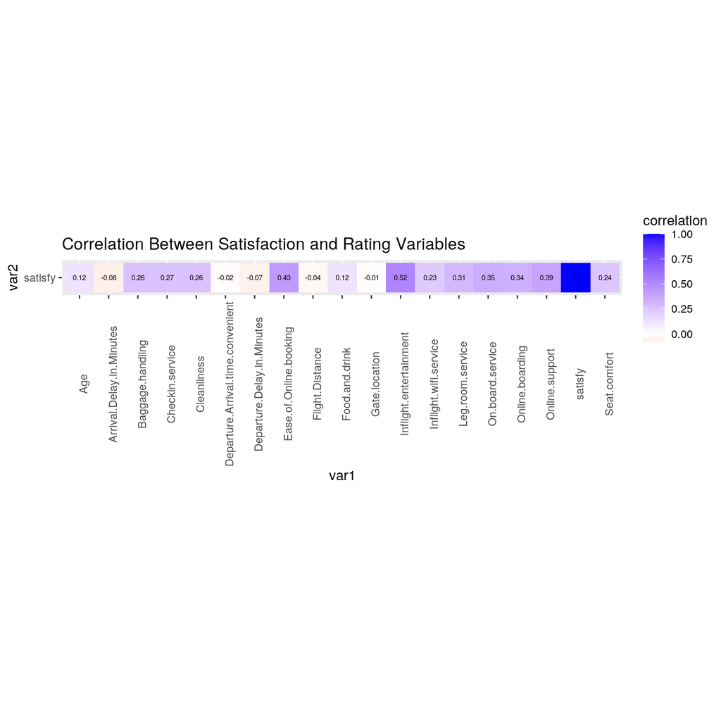

```r
tidycor2 <- cormat2 %>%
  as.data.frame %>%
  rownames_to_column("var1") %>%
  pivot_longer(-1, names_to = "var2", values_to = "correlation")
#Get every column except column 1

tidycor2 <- tidycor2 %>% filter(var2 == "satisfy")

tidycor2 %>% ggplot(aes(var1, var2, fill=correlation)) +
  geom_tile() +
  scale_fill_gradient2(low="red", mid="white", high = "blue") +
  geom_text(aes(label=round(correlation,2)),color = "black", size = 2)+ #overlays correlation values
  theme(axis.text.x = element_text(angle = 90)) + #flips the x-axis labels
  coord_fixed() + ggtitle("Correlation Between Satisfaction and Rating Variables")
```

Creating correlation map of all the demographic/independent variables

```r
flight_df_independent <- flight_df %>% mutate(satisfy = ifelse(satisfaction == "satisfied", 1, 0), gender = ifelse(Gender == "Male", 0, 1), customer.type = ifelse(Customer.Type == "Loyal Customer", 1, 0), travel.type = ifelse(Type.of.Travel == "Personal Travel", 0, 1), class = ifelse(Class == "Eco", 0, ifelse(Class == "Business", 2, 1)))

flight_df_independent <- flight_df_independent %>% select(satisfy, gender, customer.type, travel.type, class)

df3 <- flight_df_independent %>% select_if(is.numeric) %>% na.omit()
cormat3 <- df3 %>% cor()


cormat3 %>% as.data.frame %>% rownames_to_column("var1")
```

```
##            var1   satisfy       gender customer.type  travel.type        class
## 1       satisfy 1.0000000  0.212235981    0.29259225  0.109238733  0.305534630
## 2        gender 0.2122360  1.000000000   -0.03095754  0.009502786 -0.005774351
## 3 customer.type 0.2925922 -0.030957543    1.00000000 -0.308235642  0.105641394
## 4   travel.type 0.1092387  0.009502786   -0.30823564  1.000000000  0.545447086
## 5         class 0.3055346 -0.005774351    0.10564139  0.545447086  1.000000000
```

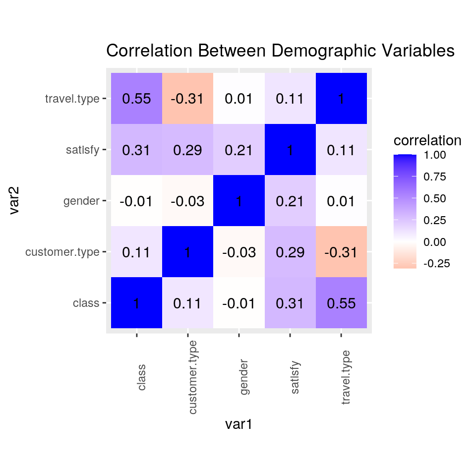

```r
tidycor3 <- cormat3 %>%
  as.data.frame %>%
  rownames_to_column("var1") %>%
  pivot_longer(-1, names_to = "var2", values_to = "correlation")
#Get every column except column 1


tidycor3 %>% ggplot(aes(var1, var2, fill=correlation)) +
  geom_tile() +
  scale_fill_gradient2(low="red", mid="white", high = "blue") +
  geom_text(aes(label=round(correlation,2)),color = "black", size = 4)+ #overlays correlation values
  theme(axis.text.x = element_text(angle = 90)) + #flips the x-axis labels
  coord_fixed() + ggtitle("Correlation Between Demographic Variables")
```

```r
#male 0, female 1
#business 2, eco plus 1, eco 0
#personal 0, business travel 1
#loyal 1, disloyal 0
#satisfy 1, disatisfy 0
```

Looking at all the numeric variables and their average rating to satisfaction

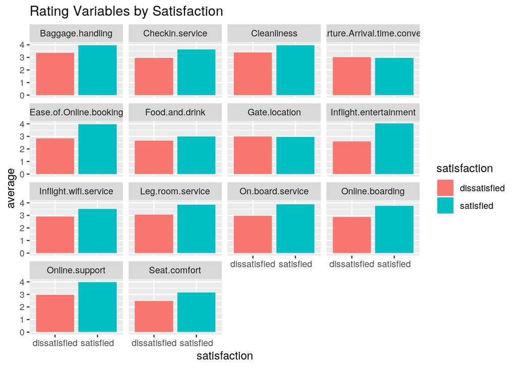

```r
m <- function(x){

  mean(x, rm.na = T)

}
average <- flight_df %>% group_by(satisfaction) %>% select_if(is.numeric) %>% summarize_all(m) %>% select(-Flight.Distance)
#average


tidy_average <- average %>% pivot_longer(cols=c('Seat.comfort':'Online.boarding'), names_to = 'flight_variable', values_to = 'average')
#tidy_average

tidy_average %>%  ggplot(aes(x = satisfaction, y = average, fill = satisfaction)) + geom_bar(stat = "identity") + facet_wrap(~flight_variable) + ggtitle("Rating Variables by Satisfaction")
```

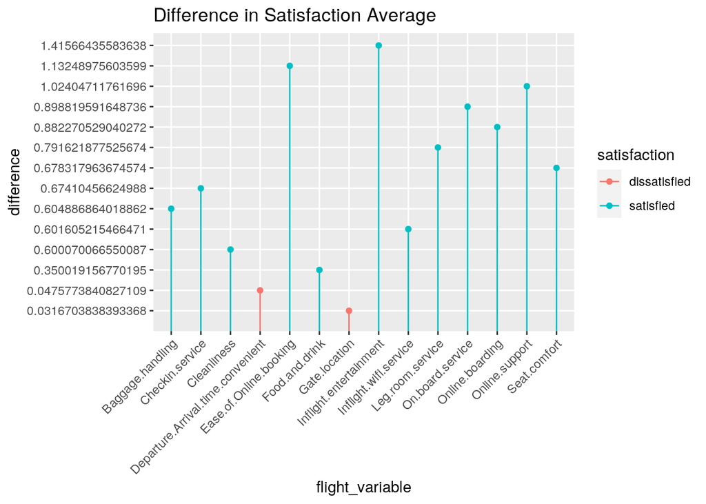

```r
difference_df <- tidy_average %>% select(flight_variable, satisfaction, average) %>% arrange(flight_variable, average) %>% mutate(diff=average-lag(average,default=first(average))) %>% mutate(difference = ifelse(diff <= 0, "-", diff)) %>% select(-diff)


difference_df %>% filter(difference != "-") %>% ggplot(aes(x = flight_variable, y=difference, color = satisfaction)) + geom_point()  + geom_segment(aes(x=flight_variable, xend=flight_variable, y=0, yend=difference)) + theme(axis.text.x = element_text(angle = 45, hjust = 1)) + ggtitle("Difference in Satisfaction Average")
```

By gender

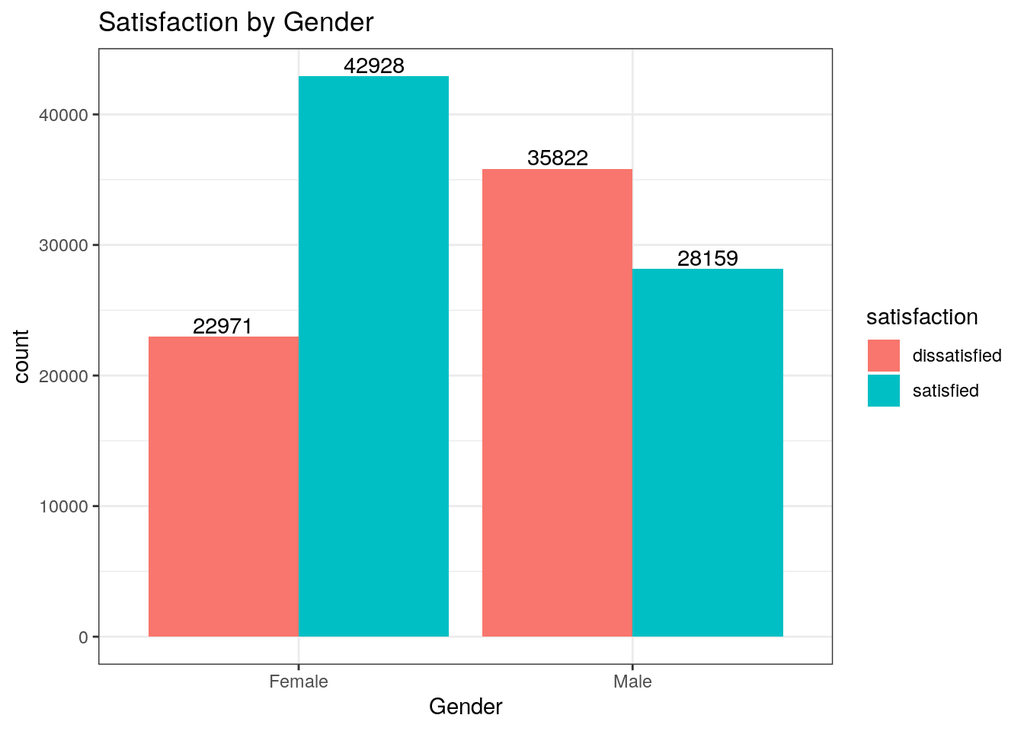

```r
ggplot(data = flight_df, aes(x = Gender, fill = satisfaction)) + geom_bar(position="dodge") +  geom_text(stat="count", aes(label=..count..), position=position_dodge(width=0.9), vjust=-0.2) + theme_bw() + ggtitle("Satisfaction by Gender")
```

By customer type

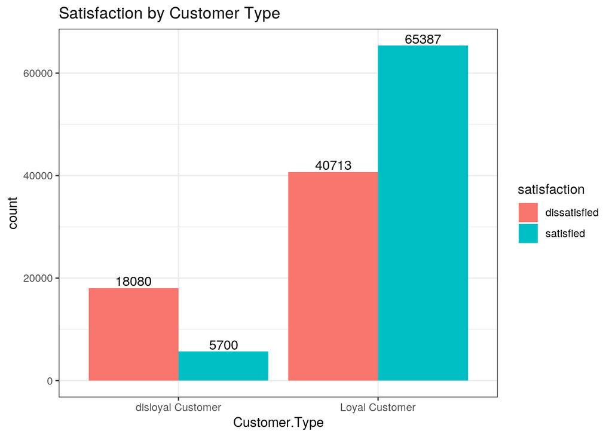

```r
ggplot(data = flight_df, aes(x = Customer.Type, fill = satisfaction)) + geom_bar(position="dodge") +  geom_text(stat="count", aes(label=..count..), position=position_dodge(width=0.9), vjust=-0.2) + theme_bw() + ggtitle("Satisfaction by Customer Type")
```

By type of travel

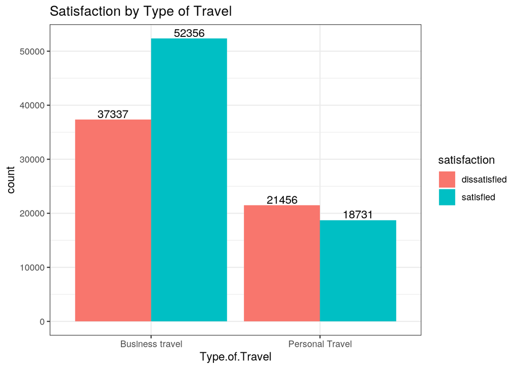

```r
ggplot(data = flight_df, aes(x = Type.of.Travel , fill = satisfaction)) + geom_bar(position="dodge") +  geom_text(stat="count", aes(label=..count..), position=position_dodge(width=0.9), vjust=-0.2) + theme_bw() + ggtitle("Satisfaction by Type of Travel")
```

By class

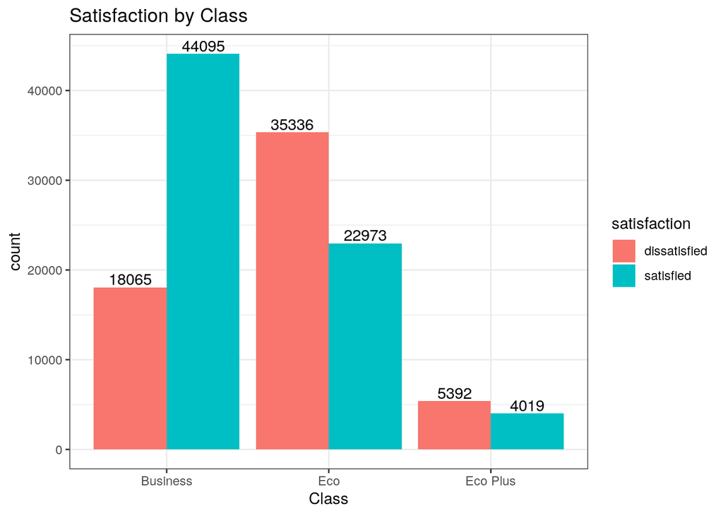

```r
ggplot(data = flight_df, aes(x = Class , fill = satisfaction)) + geom_bar(position="dodge") +  geom_text(stat="count", aes(label=..count..), position=position_dodge(width=0.9), vjust=-0.2) + theme_bw() + ggtitle("Satisfaction by Class")
```

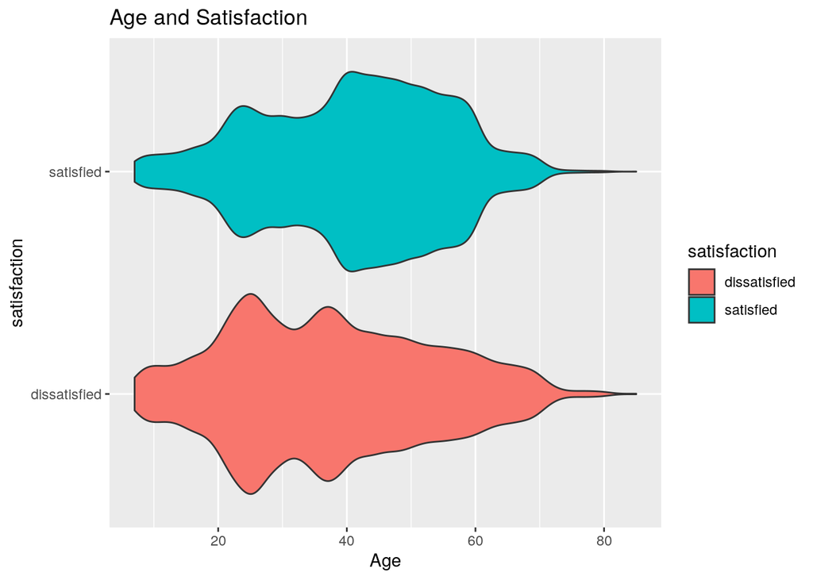

```r
flight_df %>% ggplot(aes(x = Age, y= satisfaction, fill = satisfaction)) + geom_violin() + ggtitle("Age and Satisfaction")
```

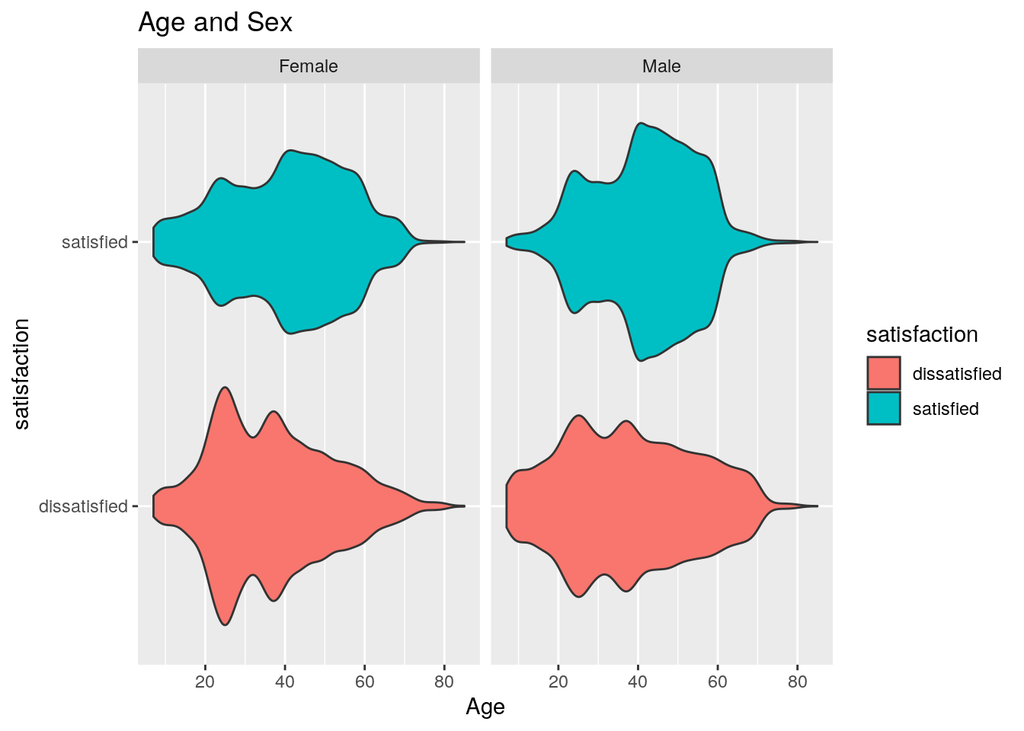

```r
flight_df %>% ggplot(aes(x = Age, y= satisfaction, fill = satisfaction)) + geom_violin() + facet_wrap(~Gender) + ggtitle("Age and Sex")
```

Clustering

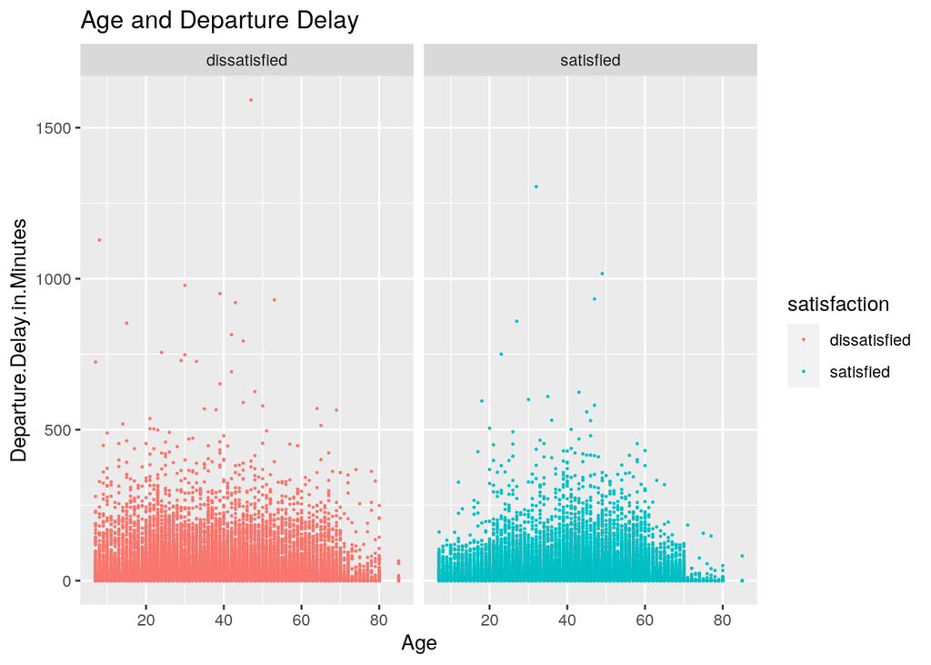

```r
flight_df %>% ggplot(aes(x = Age, y = Departure.Delay.in.Minutes, color = satisfaction)) + geom_point(size = .2) + facet_wrap(~satisfaction) + ggtitle("Age and Departure Delay")
```

```r
#flight_df %>% ggplot(aes(x = Age, y = Flight.Distance, color = satisfaction)) + geom_point(size = .2) + facet_wrap(~satisfaction)

clust_dat <- flight_df %>% select(Age, Departure.Delay.in.Minutes)

kmeans1 <- clust_dat %>% kmeans(4) #set number of clusters k

kmeansclust <- clust_dat %>% mutate(cluster=as.factor(kmeans1$cluster))
```

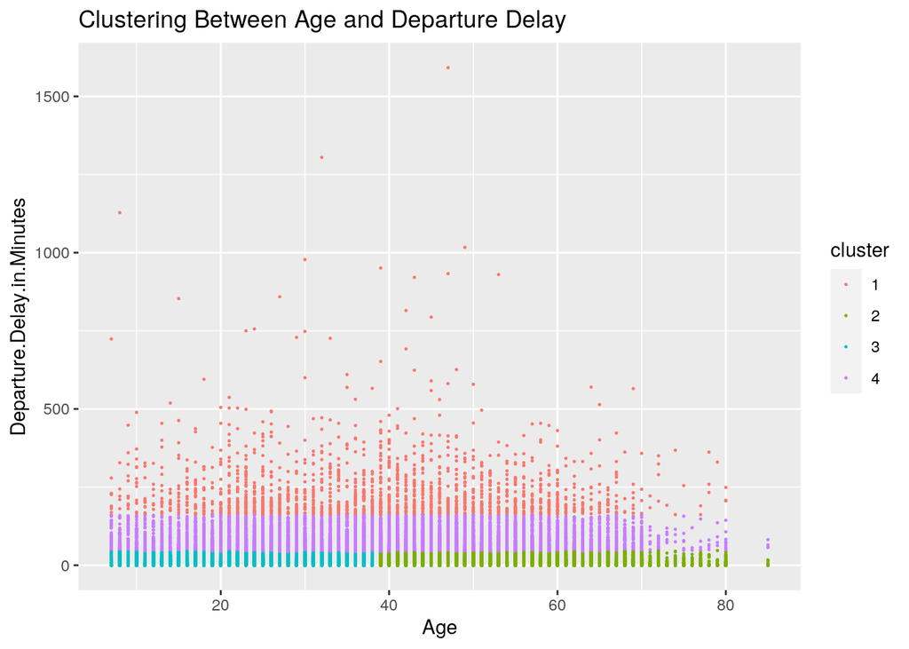

```r
kmeansclust %>% ggplot(aes(x = Age, y = Departure.Delay.in.Minutes, color = cluster)) + geom_point(size = .2) + ggtitle("Clustering Between Age and Departure Delay")
```

Doing some data analysis to to determine the clustering and the class they belong to

```r
join_cluster <- flight_df %>% select(satisfaction, Age, Departure.Delay.in.Minutes, Class)

temp <- inner_join(join_cluster, kmeansclust, by = c("Age", "Departure.Delay.in.Minutes")) %>% distinct() %>% group_by(cluster, Class) %>% summarize(satisfy = sum(satisfaction == "satisfied"), nosatisfy = sum(satisfaction == "dissatisfied")) %>% arrange(desc(nosatisfy))
temp
```

```
## # A tibble: 12 × 4
## # Groups:   cluster [4]
##    cluster Class    satisfy nosatisfy
##    <fct>   <chr>      <int>     <int>
##  1 4       Eco         1390      2563
##  2 4       Business    2155      1511
##  3 2       Eco         1147      1326
##  4 3       Eco         1131      1304
##  5 2       Business    1174      1162
##  6 3       Business     980       996
##  7 3       Eco Plus     476       664
##  8 1       Eco          121       643
##  9 2       Eco Plus     497       638
## 10 4       Eco Plus     267       567
## 11 1       Business     439       298
## 12 1       Eco Plus      19        98
```

Analyzing our clustering soultion

```r
wss<-vector() #create empty vector

#for k=1, 2, ... 10, compute WSS and save it in wss
for(i in 1:10){
  temp2 <- flight_df %>% select(Age,Departure.Delay.in.Minutes) %>% kmeans(i)
  wss[i] <- temp2$tot.withinss # tot.withinss = WSS
}

wss
```

```
##  [1] 217937702 104118192  84630133  52495112  37930686  33762405  26904641
##  [8]  25514795  20096149  19027417
```

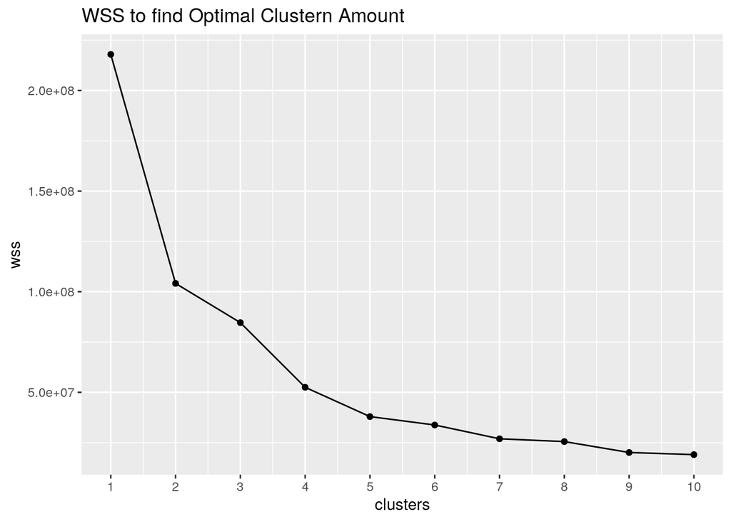

```r
ggplot()+geom_point(aes(x=1:10,y=wss))+geom_path(aes(x=1:10,y=wss))+
  xlab("clusters")+scale_x_continuous(breaks=1:10) + ggtitle("WSS to find Optimal Clustern Amount")
```

More visuzlations about class type and flight distance

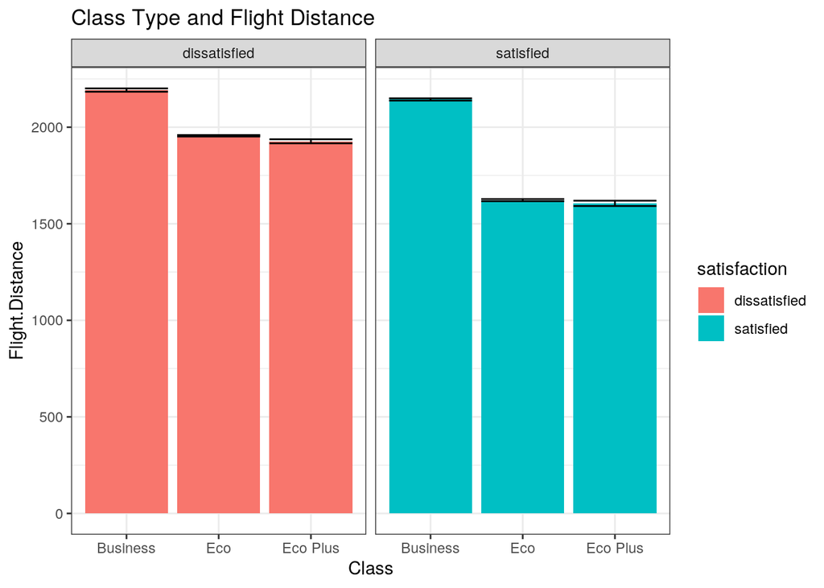

```r
ggplot(flight_df, aes(x = Class, y = Flight.Distance, fill = satisfaction)) + geom_bar(stat = "summary", fun=mean, position="dodge") + geom_errorbar(stat="summary", fun.data = mean_se) + facet_wrap(~satisfaction) + theme_bw() + ggtitle("Class Type and Flight Distance")
```

Leg room and type of travel

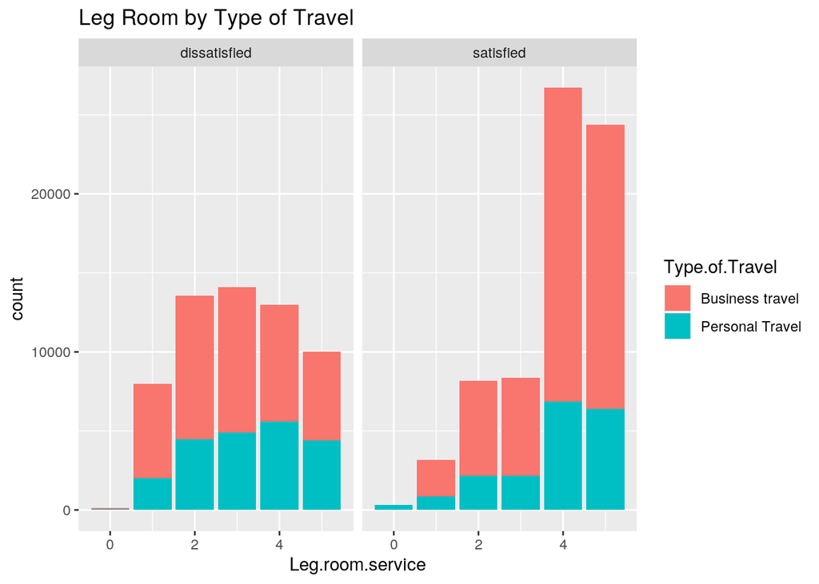

```r
flight_df %>% ggplot(aes(x = Leg.room.service, fill = Type.of.Travel)) + geom_bar(stat = "count") + facet_wrap(~satisfaction) + ggtitle("Leg Room by Type of Travel")
```

Gender overall distribution

```r
flight_df %>% group_by(Gender) %>% summarize(male = sum(Gender == "Male"), female = sum(Gender == "Female"))
```

```
## # A tibble: 2 × 3
##   Gender  male female
##   <chr>  <int>  <int>
## 1 Female     0  65899
## 2 Male   63981      0
```

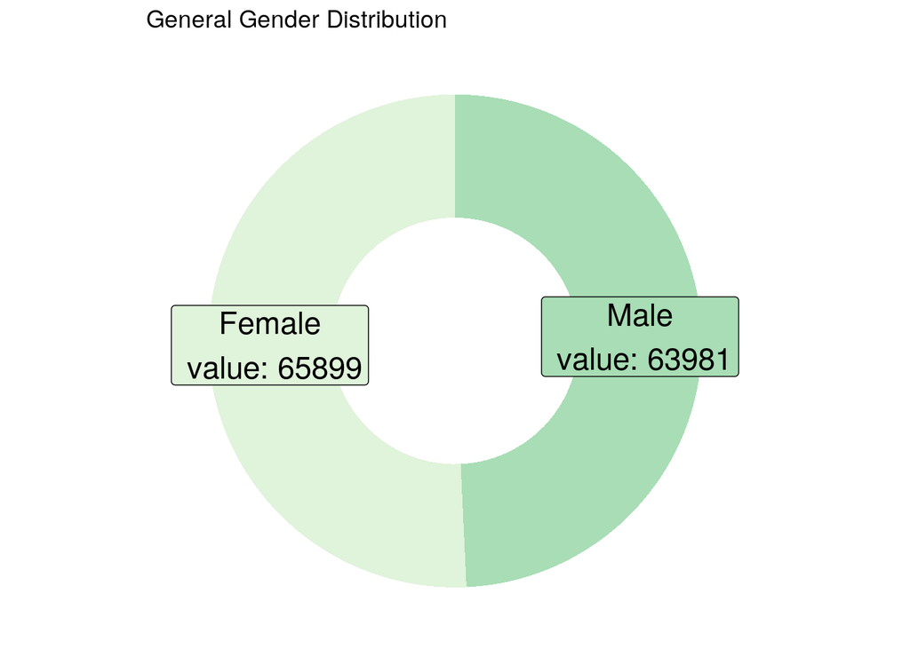

```r
data <- data.frame(
  category=c("Male", "Female"),
  count=c(63981, 65899)
)

# Compute percentages
data$fraction <- data$count / sum(data$count)

# Compute the cumulative percentages (top of each rectangle)
data$ymax <- cumsum(data$fraction)

# Compute the bottom of each rectangle
data$ymin <- c(0, head(data$ymax, n=-1))

# Compute label position
data$labelPosition <- (data$ymax + data$ymin) / 2

# Compute a good label
data$label <- paste0(data$category, "\n value: ", data$count)

# Make the plot
ggplot(data, aes(ymax=ymax, ymin=ymin, xmax=4, xmin=3, fill=category)) +
  geom_rect() +
  geom_label( x=3.5, aes(y=labelPosition, label=label), size=6) +
  scale_fill_brewer(palette=4) +
  coord_polar(theta="y") +
  xlim(c(2, 4)) + theme_void() +
  theme(legend.position = "none") + ggtitle("General Gender Distribution")
```

Leg room count by gender

```r
flight_df %>%group_by(`Leg.room.service`,Gender)%>%summarise(count=n())
```

```
## # A tibble: 12 × 3
## # Groups:   Leg.room.service [6]
##    Leg.room.service Gender count
##               <int> <chr>  <int>
##  1                0 Female   364
##  2                0 Male      80
##  3                1 Female  4937
##  4                1 Male    6204
##  5                2 Female  9952
##  6                2 Male   11793
##  7                3 Female 10250
##  8                3 Male   12217
##  9                4 Female 21868
## 10                4 Male   17830
## 11                5 Female 18528
## 12                5 Male   15857
```

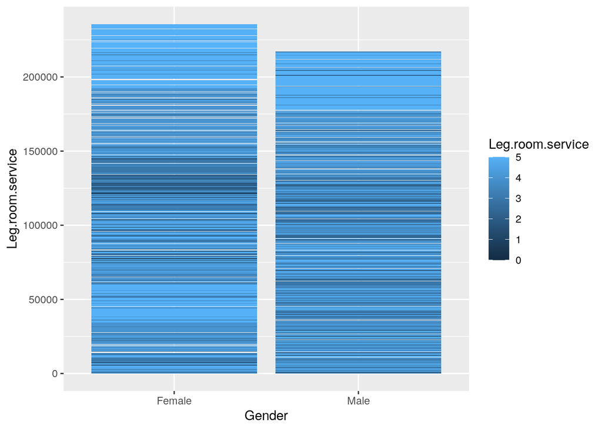

```r
ggplot(flight_df, aes(x=Gender,y=`Leg.room.service`,fill=`Leg.room.service`))+geom_bar(stat="identity")
```

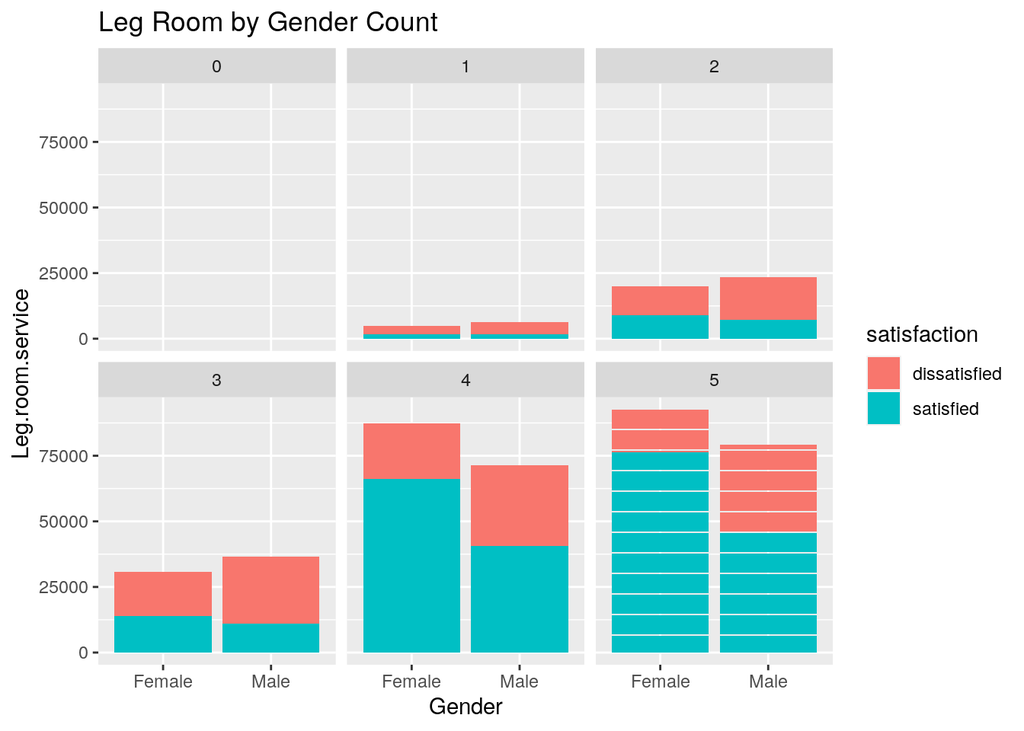

```r
ggplot(flight_df,aes(x=Gender,y=Leg.room.service,fill=satisfaction))+
  geom_bar(stat="identity")+ facet_wrap(~Leg.room.service)  + ggtitle("Leg Room by Gender Count")
```

```r
flights_gender <- flight_df %>% mutate(gender = ifelse(Gender == "Male", 0, 1))



df3 <- flights_gender %>% select_if(is.numeric) %>% na.omit()
cormat3 <- df3 %>% cor()



cormat3 %>% as.data.frame %>% rownames_to_column("var1")
```

```
##                                 var1           Age Flight.Distance Seat.comfort
## 1                                Age  1.0000000000    -0.249438178  0.008474937
## 2                    Flight.Distance -0.2494381776     1.000000000 -0.042476218
## 3                       Seat.comfort  0.0084749369    -0.042476218  1.000000000
## 4  Departure.Arrival.time.convenient  0.0389045982     0.001380637  0.434944690
## 5                     Food.and.drink  0.0154957058    -0.004806365  0.716007667
## 6                      Gate.location -0.0008049599    -0.002321616  0.405358235
## 7              Inflight.wifi.service  0.0140367279     0.012313559  0.129151961
## 8             Inflight.entertainment  0.1302542340    -0.027344333  0.426487945
## 9                     Online.support  0.1212867293    -0.031859699  0.120153416
## 10            Ease.of.Online.booking  0.0717278697    -0.022325502  0.211576238
## 11                  On.board.service  0.0665097673    -0.032421850  0.121182929
## 12                  Leg.room.service  0.0836836105    -0.030220028  0.136160590
## 13                  Baggage.handling -0.0155537358     0.019652907  0.118557154
## 14                   Checkin.service  0.0315557704     0.002530924  0.041264611
```

[output cut: 105 more lines]

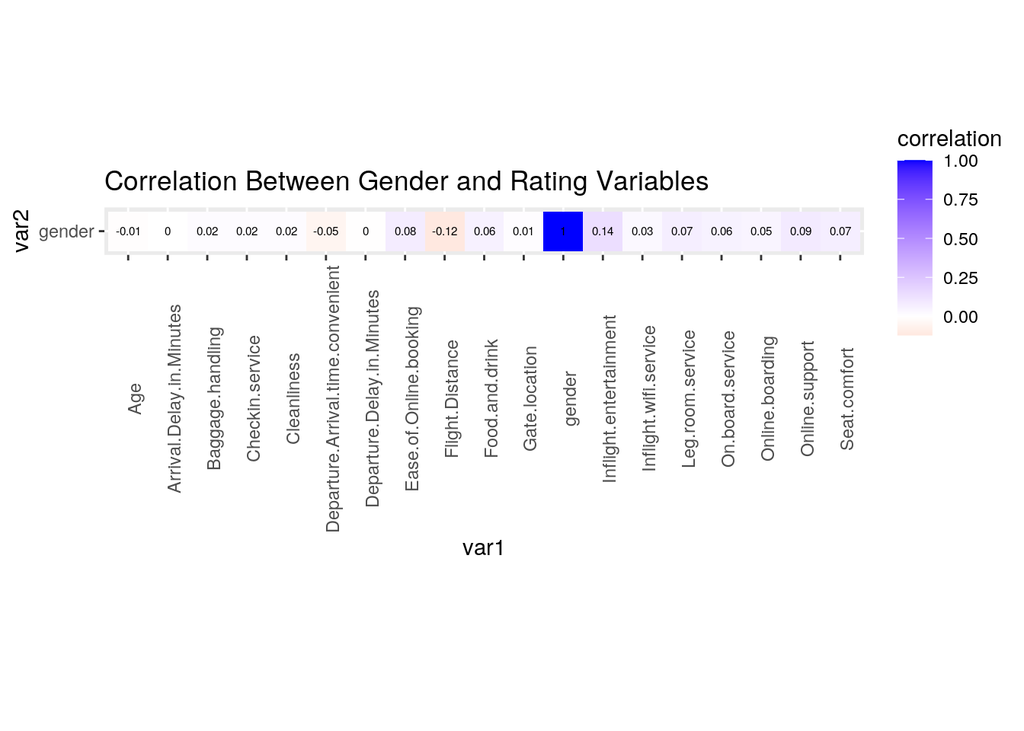

```r
tidycor3 <- cormat3 %>%
  as.data.frame %>%
  rownames_to_column("var1") %>%
  pivot_longer(-1, names_to = "var2", values_to = "correlation")
#Get every column except column 1

tidycor3 <- tidycor3 %>% filter(var2 == "gender")



tidycor3 %>% ggplot(aes(var1, var2, fill=correlation)) +
  geom_tile() +
  scale_fill_gradient2(low="red", mid="white", high = "blue") +
  geom_text(aes(label=round(correlation,2)),color = "black", size = 2)+ #overlays correlation values
  theme(axis.text.x = element_text(angle = 90)) + #flips the x-axis labels
  coord_fixed() + ggtitle("Correlation Between Gender and Rating Variables")
```

Correlation map for male flyers

```r
flight_df_gender <- flight_df %>% mutate(Gender = ifelse(Gender == "Male", 0, 1)) %>% mutate(satisfaction = ifelse(satisfaction == "satisfied", 1, 0)) %>% filter(Gender == 0)
head(flight_df_gender)
```

```
##   satisfaction Gender  Customer.Type Age  Type.of.Travel    Class
## 1            1      0 Loyal Customer  47 Personal Travel Business
## 2            1      0 Loyal Customer  30 Personal Travel      Eco
## 3            1      0 Loyal Customer  10 Personal Travel      Eco
## 4            1      0 Loyal Customer  22 Personal Travel      Eco
## 5            1      0 Loyal Customer  62 Personal Travel      Eco
## 6            1      0 Loyal Customer  35 Personal Travel      Eco
##   Flight.Distance Seat.comfort Departure.Arrival.time.convenient Food.and.drink
## 1            2464            0                                 0              0
## 2            1894            0                                 0              0
## 3            1812            0                                 0              0
## 4            1556            0                                 0              0
## 5            1695            0                                 0              0
## 6            1766            0                                 1              0
##   Gate.location Inflight.wifi.service Inflight.entertainment Online.support
```

[output cut: 27 more lines]

```r
df2 <- flight_df_gender %>% select_if(is.numeric) %>% na.omit()
cormat2 <- df2 %>% cor()
cormat2 %>% as.data.frame %>% rownames_to_column("var1")
```

```
##                                 var1 satisfaction Gender          Age
## 1                       satisfaction  1.000000000     NA  0.129640888
## 2                             Gender           NA      1           NA
## 3                                Age  0.129640888     NA  1.000000000
## 4                    Flight.Distance  0.020154707     NA -0.139033427
## 5                       Seat.comfort  0.284123004     NA  0.009158195
## 6  Departure.Arrival.time.convenient -0.062814811     NA  0.030445998
## 7                     Food.and.drink  0.169048532     NA  0.017104146
## 8                      Gate.location  0.001027462     NA  0.001587048
## 9              Inflight.wifi.service  0.242217387     NA  0.015517383
## 10            Inflight.entertainment  0.570707111     NA  0.135943530
## 11                    Online.support  0.394888644     NA  0.115940625
## 12            Ease.of.Online.booking  0.404218055     NA  0.071884723
## 13                  On.board.service  0.295769155     NA  0.059337634
## 14                  Leg.room.service  0.253386778     NA  0.074940912
```

[output cut: 111 more lines]

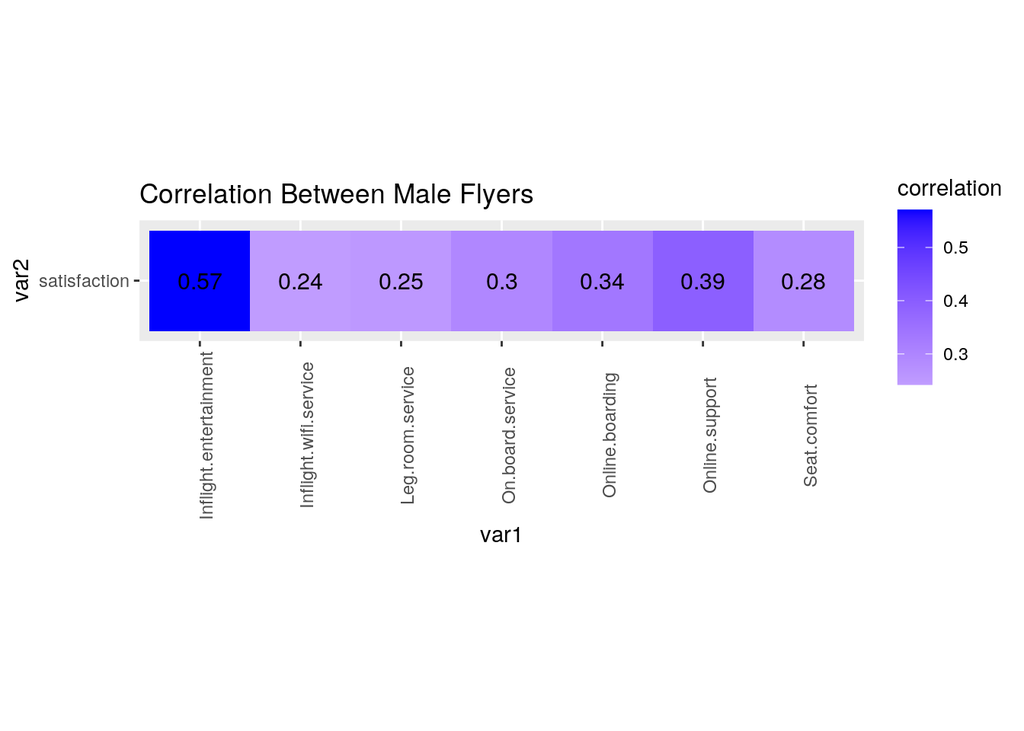

```r
tidycor2 <- cormat2 %>%
  as.data.frame %>%
  rownames_to_column("var1") %>%
  pivot_longer(-1, names_to = "var2", values_to = "correlation")
#Get every column except column 1

tidycor2 <- tidycor2 %>% filter(var2 == "satisfaction") %>% filter (var1=="Inflight.entertainment" | var1=="Leg.room.service"
            | var1=="Online.boarding"
            | var1=="Online.support"
            | var1=="Seat.comfort"
            | var1=="On.board.service"
            | var1=="Inflight.wifi.service")

tidycor2 %>% ggplot(aes(var1, var2, fill=correlation)) +
  geom_tile() +
  scale_fill_gradient2(low="red", mid="white", high = "blue") +
  geom_text(aes(label=round(correlation,2)),color = "black", size = 4)+ #overlays correlation values
  theme(axis.text.x = element_text(angle = 90)) + #flips the x-axis labels
  coord_fixed() + ggtitle("Correlation Between Male Flyers")
```

Correlation map for female flyers

```r
flight_df_gender <- flight_df %>% mutate(Gender = ifelse(Gender == "Male", 0, 1)) %>% mutate(satisfaction = ifelse(satisfaction == "satisfied", 1, 0)) %>% filter(Gender == 1)
head(flight_df_gender)
```

```
##   satisfaction Gender  Customer.Type Age  Type.of.Travel    Class
## 1            1      1 Loyal Customer  65 Personal Travel      Eco
## 2            1      1 Loyal Customer  15 Personal Travel      Eco
## 3            1      1 Loyal Customer  60 Personal Travel      Eco
## 4            1      1 Loyal Customer  70 Personal Travel      Eco
## 5            1      1 Loyal Customer  66 Personal Travel      Eco
## 6            1      1 Loyal Customer  56 Personal Travel Business
##   Flight.Distance Seat.comfort Departure.Arrival.time.convenient Food.and.drink
## 1             265            0                                 0              0
## 2            2138            0                                 0              0
## 3             623            0                                 0              0
## 4             354            0                                 0              0
## 5             227            0                                 0              0
## 6              73            0                                 0              0
##   Gate.location Inflight.wifi.service Inflight.entertainment Online.support
```

[output cut: 27 more lines]

```r
df2 <- flight_df_gender %>% select_if(is.numeric) %>% na.omit()
cormat2 <- df2 %>% cor()
cormat2 %>% as.data.frame %>% rownames_to_column("var1")
```

```
##                                 var1 satisfaction Gender          Age
## 1                       satisfaction   1.00000000     NA  0.115583231
## 2                             Gender           NA      1           NA
## 3                                Age   0.11558323     NA  1.000000000
## 4                    Flight.Distance  -0.04458952     NA -0.350392179
## 5                       Seat.comfort   0.18604911     NA  0.009150406
## 6  Departure.Arrival.time.convenient   0.05418056     NA  0.046290975
## 7                     Food.and.drink   0.05501078     NA  0.015099846
## 8                      Gate.location  -0.03061768     NA -0.002856503
## 9              Inflight.wifi.service   0.20844064     NA  0.013159101
## 10            Inflight.entertainment   0.44534526     NA  0.129802315
## 11                    Online.support   0.36596113     NA  0.129590713
## 12            Ease.of.Online.booking   0.44843970     NA  0.073608121
## 13                  On.board.service   0.40320083     NA  0.074822475
## 14                  Leg.room.service   0.34313909     NA  0.094064364
```

[output cut: 111 more lines]

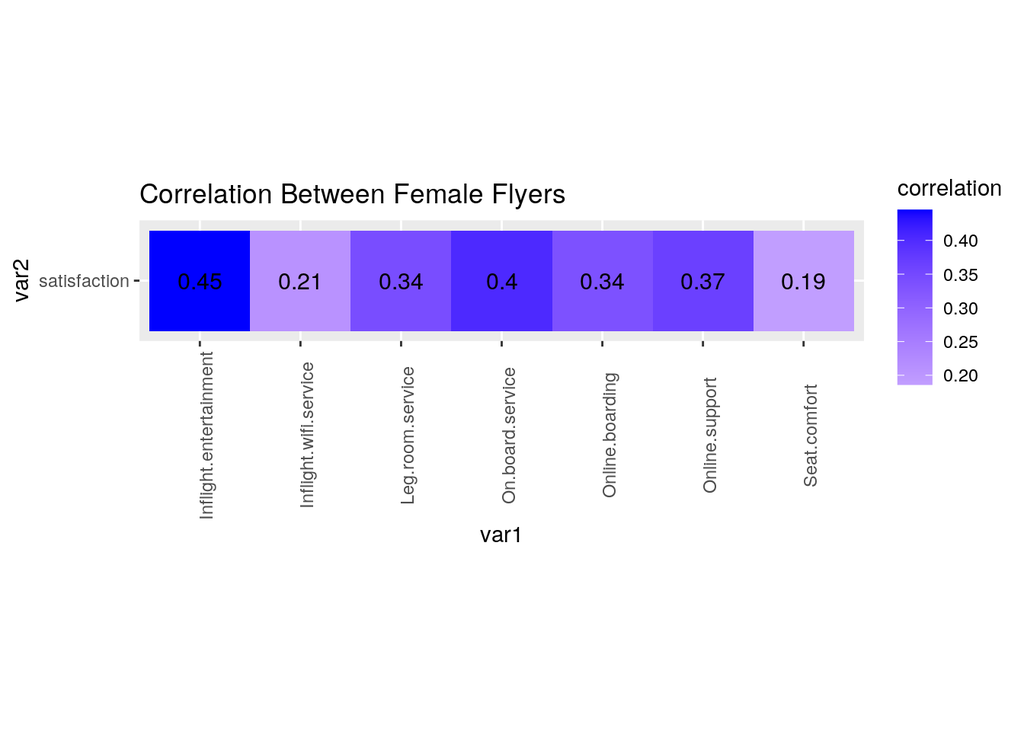

```r
tidycor2 <- cormat2 %>%
  as.data.frame %>%
  rownames_to_column("var1") %>%
  pivot_longer(-1, names_to = "var2", values_to = "correlation")
#Get every column except column 1

tidycor2 <- tidycor2 %>% filter(var2 == "satisfaction") %>% filter (var1=="Inflight.entertainment" | var1=="Leg.room.service"
            | var1=="Online.boarding"
            | var1=="Online.support"
            | var1=="Seat.comfort"
            | var1=="On.board.service"
            | var1=="Inflight.wifi.service")

tidycor2 %>% ggplot(aes(var1, var2, fill=correlation)) +
  geom_tile() +
  scale_fill_gradient2(low="red", mid="white", high = "blue") +
  geom_text(aes(label=round(correlation,2)),color = "black", size = 4)+ #overlays correlation values
  theme(axis.text.x = element_text(angle = 90)) + #flips the x-axis labels
  coord_fixed() + ggtitle("Correlation Between Female Flyers")
```

Categorizing Age

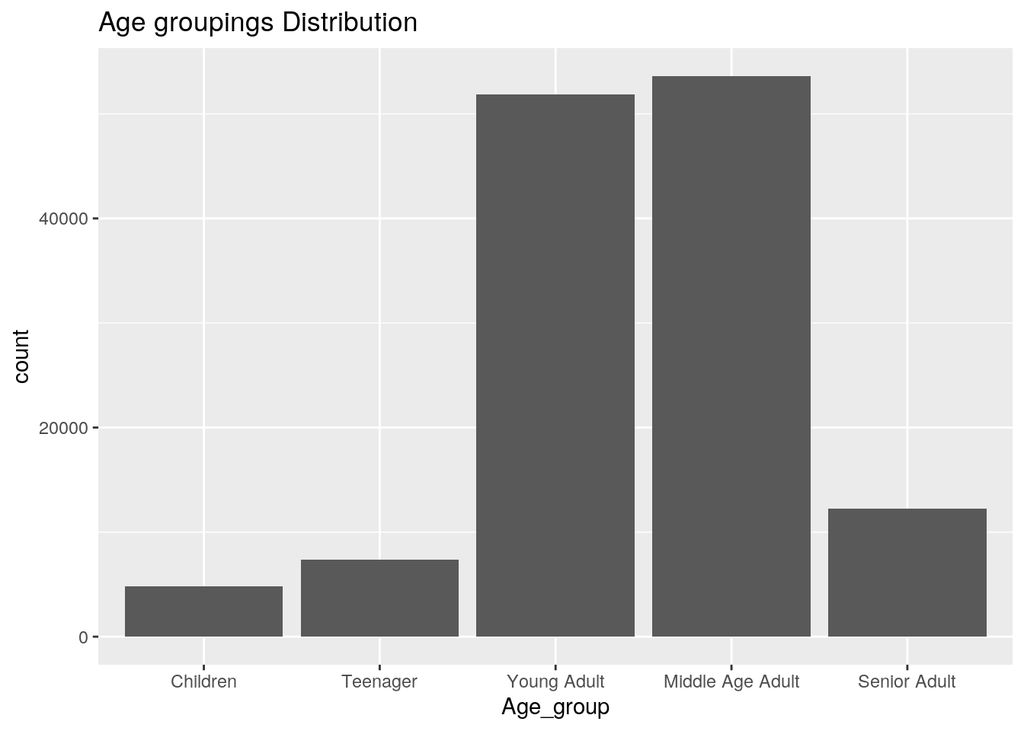

```r
flight_df$Age_group <- cut(flight_df$Age,
                        breaks = c(6, 12, 19, 39, 59, 85),
                        labels = c("Children","Teenager","Young Adult","Middle Age Adult",
                                   "Senior Adult"))
flight_df %>% ggplot(aes(x=Age_group)) + geom_bar(stat="count") + ggtitle("Age groupings Distribution")
```

Categorizing Age by intervals of 10

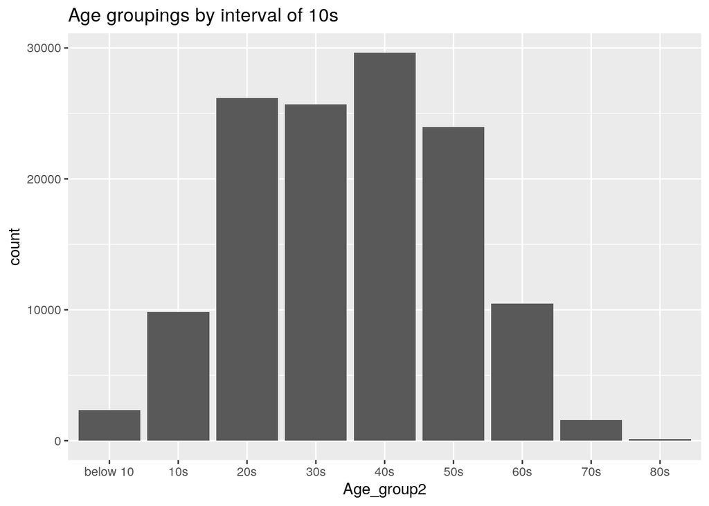

```r
flight_df$Age_group2 <- cut(flight_df$Age,
                        breaks = c(0, 9, 19, 29, 39, 49, 59, 69, 79, 89),
                        labels = c("below 10", "10s","20s","30s","40s", "50s", "60s", "70s", "80s"))

flight_df %>% ggplot(aes(x=Age_group2)) + geom_bar(stat="count") + ggtitle("Age groupings by interval of 10s")
```

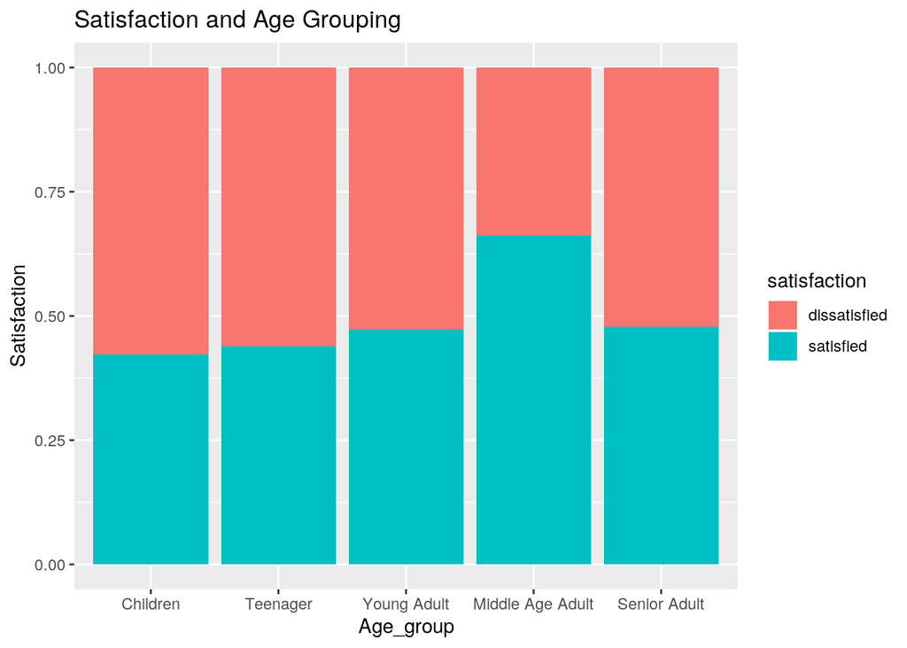

```r
flight_df %>%
  ggplot(aes(x = Age_group, fill=satisfaction)) +
  geom_bar(position = "fill") + ylab("Satisfaction") + ggtitle("Satisfaction and Age Grouping")
```

Categorize departure and arrival delay variables

```r
flight_df$DepartureDelay_group <- cut(flight_df$Departure.Delay.in.Minutes,
                        breaks = c(-1, 0, 10, 20, 30, 60, 120, 180, 1600),
                        labels = c("Punctual", "1~10min late", "11~20min late", "21~30min late",
                                   "31~60min late", "61~120min late", "121~180min late",
                                   "more than 180min late"))

flight_df$ArrivalDelay_group <- cut(flight_df$Arrival.Delay.in.Minutes,
                        breaks = c(-1, 0, 10, 20, 30, 60, 120, 180, 1600),
                        labels = c("Punctual", "1~10min late", "11~20min late", "21~30min late",
                                   "31~60min late", "61~120min late", "121~180min late",
                                   "more than 180min late"))

# change satisfaction variable to numeric variable(0,1)
flight2 <- flight_df %>% mutate(satisfaction=ifelse(satisfaction=="satisfied",1,0))

# Make a dataframe that shows satisfaction ratio grouped by age group and delay group
flight_ratio <- flight2 %>%
  group_by(Age_group, DepartureDelay_group) %>%
  summarize(sat_ratio = sum(satisfaction)/n()) %>%
  mutate(sat_ratio = round(sat_ratio, digit=2))
```

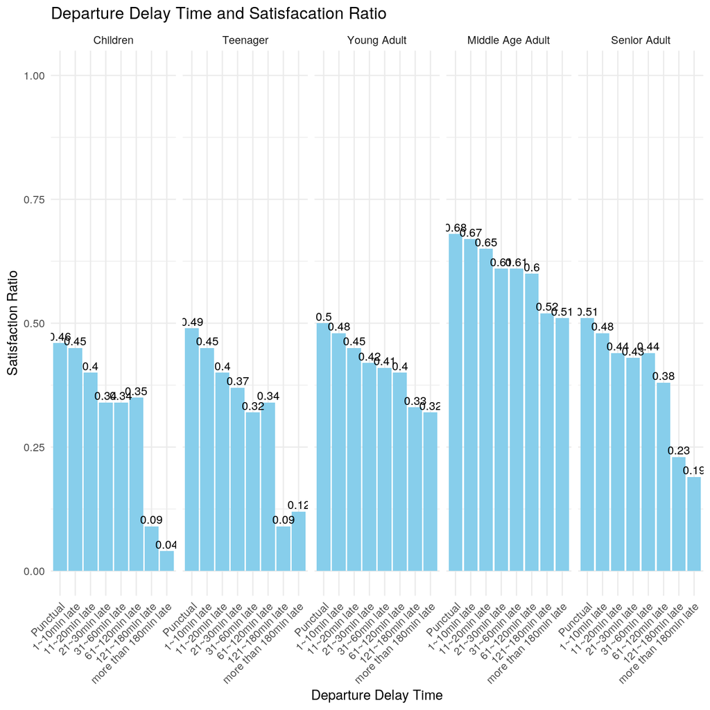

```r
flight_ratio %>%
  ggplot(aes(x=DepartureDelay_group, y=sat_ratio)) +
  geom_bar(stat='identity', fill = "skyblue") +
  facet_wrap(~Age_group, ncol=5) +
  geom_text(aes(label = sat_ratio), vjust = -0.3, size=3.3) +
  theme_minimal() +
  theme(axis.text.x = element_text(angle = 45, vjust = 1, hjust=1)) +
  xlab("Departure Delay Time") + ylab("Satisfaction Ratio") +
  ylim(0,1) + ggtitle("Departure Delay Time and Satisfacation Ratio")
```

```r
# change satisfaction variable to numeric variable(0,1)
flight2 <- flight_df %>% mutate(sat=ifelse(satisfaction=="satisfied",1,0))

# Make a dataframe that shows satisfaction ratio grouped by age group and delay group
flight_ratio2 <- flight2 %>%
  group_by(Age_group, Ease.of.Online.booking) %>%
  summarize(sat_ratio = sum(sat)/n()) %>%
  mutate(sat_ratio = round(sat_ratio, digit=2))
```

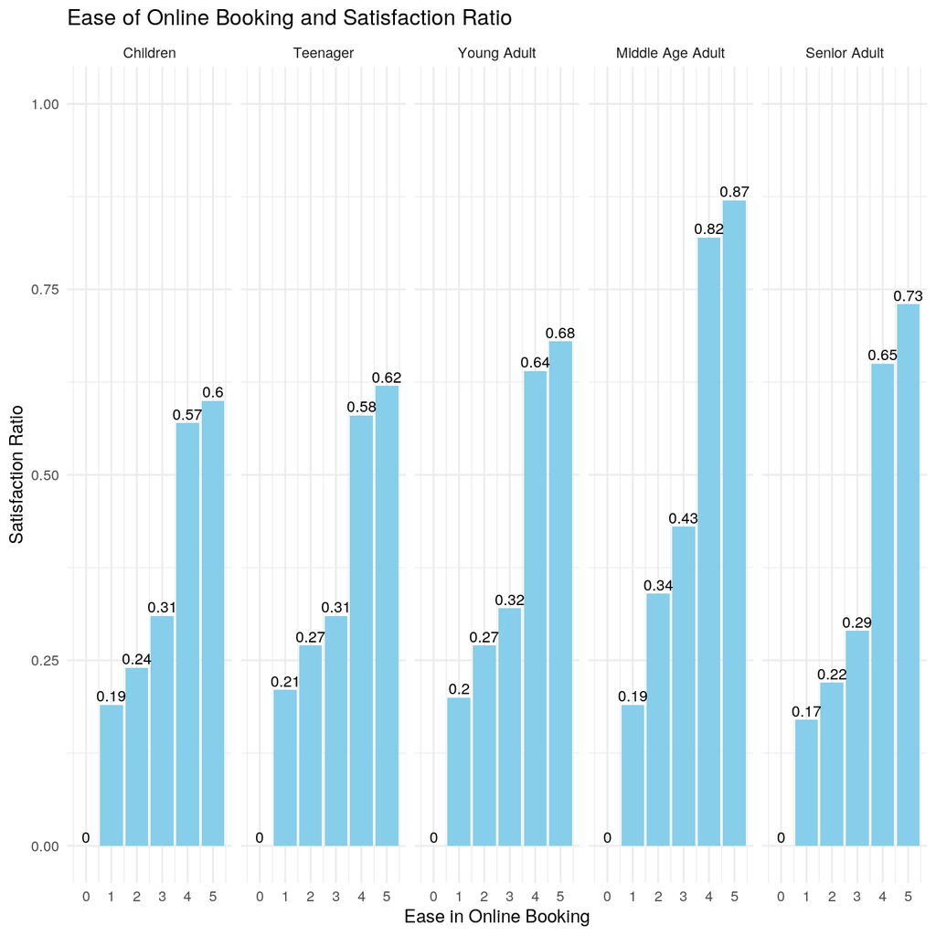

```r
## `summarise()` has grouped output by 'Age_group'. You can override using the
## `.groups` argument.
flight_ratio2 %>%
  ggplot(aes(x=Ease.of.Online.booking, y=sat_ratio)) +
  geom_bar(stat='identity', fill = "skyblue") +
  facet_wrap(~Age_group, ncol=5) +
  geom_text(aes(label = sat_ratio), vjust = -0.3, size=3.3) +
  theme_minimal() +
  #theme(axis.text.x = element_text(angle = 45, vjust = 1, hjust=1)) +
  ylab("Satisfaction Ratio") +
  scale_x_continuous(name = "Ease in Online Booking", breaks = seq(0, 5, by = 1)) +
  ylim(0,1) + ggtitle("Ease of Online Booking and Satisfaction Ratio")
```